# data_fix

2017-02-21 17:00:43

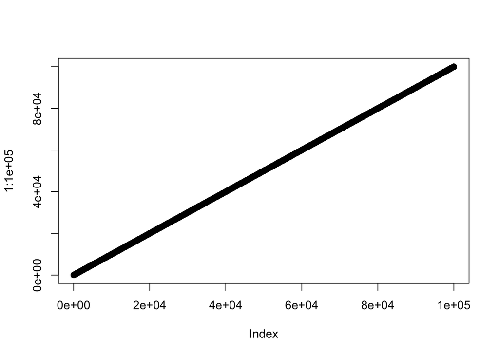

```r
library(stats)

plot(1:100000)
```

```r
n <- 5
rep(1:n, each=200)
```

[output not shown]

```r
x <- 99
c <- 1 - (1 - (x/100))/2
c
```

```
## [1] 0.995
```

```r
cv <- function(x) {

  c <- 1 - (1 - (x/100))/2
  return(c)

}


a <- 5
s <- 2
n <- 20
c <- 99


error <- qnorm(cv(c))*s/sqrt(n)
left <- a - error
right <- a + error
left
```

```
## [1] 3.848054
```

```r
right
```

```
## [1] 6.151946
```

```r
x <- 62.7
s2 <- 25
s <- sqrt(s)
n <- 100
c <- 95

error <- qnorm(cv(c))*s/sqrt(n)
left <- x - error
right <- x + error
left
```

```
## [1] 62.42282
```

```r
right
```

```
## [1] 62.97718
```

2. 달콤한 풍선껌은 50개의 풍선껌으로 이루어진 표본에서 빨강색 풍선껌의 비율이 0.25라는 사실을 발견했습니다. 모집단에 있는 빨강색 풍선껌의 비율에 대해 99% 신뢰구간을 만들어보세요.

```r
#Binomial

n <- 50
p <- 0.25
q <- 0.75
c <- 99

error <- qnorm(cv(c)) * sqrt(p*q)/sqrt(n)
left <- p - error
right <- p + error
left
```

```
## [1] 0.09226331
```

```r
right
```

```
## [1] 0.4077367
```

3. 구슬 아이스크림 1컵의 무게를 알기 위하여 판매되는 것 가운데 100컵을 조사했더니 평균이 155g이고 표준 편차가 8.7g이었다. 이때 1컵의 평균 무게에 대한 99% 신뢰구간을 구하여라.

```r
n <- 100
x <- 155
s2 <- 8.7^2
s <- 8.7

error <- qnorm(0.995)*s/sqrt(n)
left <- x - error
right <- x + error
left
```

```
## [1] 152.759
```

```r
right
```

```
## [1] 157.241
```

4. 평균이 $\mu$이고 표준편차가 $\sigma = 8$인 정규푼포를 따르는 모집단으로부터 크기 $n = 25$인 확률 표본을 추출하여 표본 평균을 계산한 결과 $\bar{x} = 42.7$이었다. 모평균 $\mu$에 대한 95% 신뢰구간을 구하여라.

```r
s <- 8
n <- 25
x <- 42.7

error <- qnorm(0.975)*s/sqrt(n)
left <- x - error
right <- x + error
left
```

```
## [1] 39.56406
```

```r
right
```

```
## [1] 45.83594
```

5. H 대학교 4학년 학생들의 취업현황을 알기 위해서 4학년 전체 학생들 중 348명을 뽑아 조사해보니, 그중 92명이 취직한 것으로 조사되었다. 4학년 학생 전체의 취업률에 대한 추정값을 구하고 95% 신뢰구간을 구하시오. (edited)

```r
n <- 348
p <- 92/348
q <- (1 - p)
c <- 95

error <- qnorm(cv(c)) * sqrt(p*q)/sqrt(n)
left <- p - error
right <- p + error
left
```

```
## [1] 0.2180345
```

```r
right
```

```
## [1] 0.3107011
```

```r
c(2.7, 2.8, 3.0, 2.3, 2.3, 2.2, 2.8, 2.1, 2.4)
```

```
## [1] 2.7 2.8 3.0 2.3 2.3 2.2 2.8 2.1 2.4
```